# ¶ Assignment 3: Functions (Heart of the (Tiny) Tiger) ¶

*Agenda*: Writing functions to automate repetitive tasks; fitting statistical models.

#### INSTRUCTIONS:

- Type each one of the R commands in this lesson on the space provided below.
- You can embed an R code chunk like this:

  ```r
  summary(cars)
  ```

  ```
  ##      speed           dist
  ##  Min.   : 4.0   Min.   :  2.00
  ##  1st Qu.:12.0   1st Qu.: 26.00
  ##  Median :15.0   Median : 36.00
  ##  Mean   :15.4   Mean   : 42.98
  ##  3rd Qu.:19.0   3rd Qu.: 56.00
  ##  Max.   :25.0   Max.   :120.00
  ```

- Before you move to the next step, highlight or move the cursor to the end of the individual R command and click on **Run**. Do this for all R commands.
- After you are done click the **Knit HTML**, **Knit PDF** button (upper left window). A document will be generated that includes both content as well as the output of any embedded R code chunks within the document.
- Go to File –> Save. Name your file.
- Upload the file to the Moodle site by using the link provided.

The *gamma* distributions are a family of probability distributions defined by the density functions,

$$f(x) = \frac{x^{a-1} e^{-x/s}}{s^a
\Gamma(a)}$$

where the *gamma function* $\Gamma(a) = \int_{0}^{\infty}{u^{a-1} e^{-u} du}$ is chosen so that the total probability of all non-negative $x$ is 1. The parameter $a$ is called the *shape*, and $s$ is the *scale*. When $a=1$, this becomes the exponential distributions we saw in the first lab. The gamma probability density function is called `dgamma()` in R. You can prove (as a calculus exercise) that the expectation value of this distribution is $as$, and the variance $as^2$. If the mean and variance are known, $\mu$ and $\sigma^2$, then we can solve for the parameters,

$$a = \frac{a^2s^2}{as^2} =
\frac{\mu^2}{\sigma^2}$$
$$s =
\frac{as^2}{as} = \frac{\sigma^2}{\mu}$$

In this lab, you will fit a gamma distribution to data, and estimate the uncertainty in the fit.

Our data today are measurements of the weight of the hearts of 144 cats.

# Part I

##### Problem 1. (10 points)

The data is contained in a data frame called `cats`, in the R package `MASS`. (This package is part of the standard R installation.) This records the sex of each cat, its weight in kilograms, and the weight of its heart in grams. Load the data as follows:

```r
library(MASS)
data(cats)
```

Run `summary(cats)` and explain the results.

##### Solution

Type your answer here

```r
summary(cats)
```

```
##  Sex         Bwt             Hwt
##  F:47   Min.   :2.000   Min.   : 6.30
##  M:97   1st Qu.:2.300   1st Qu.: 8.95
##         Median :2.700   Median :10.10
##         Mean   :2.724   Mean   :10.63
##         3rd Qu.:3.025   3rd Qu.:12.12
##         Max.   :3.900   Max.   :20.50
```

```r
"the summary of cats shows that of the 144 cats, 47 are female and 97 are male. it also shows data about the cats wieghts and heart wieghts. that mean weight for that cats in kg is 2.724 with a min of 2kg and a max of 3.9kg. the mean weight for the cats hearts in grams is 10.63 with a min of 6.3g and a max of 20.5g"
```

[output not shown]

##### Problem 2. (10 points)

Plot a histogram of these weights using the `probability=TRUE` option. Add a vertical line with your calculated mean using `abline(v=yourmeanvaluehere)`. Does this calculated mean look correct?

##### Solution

Type your answer here

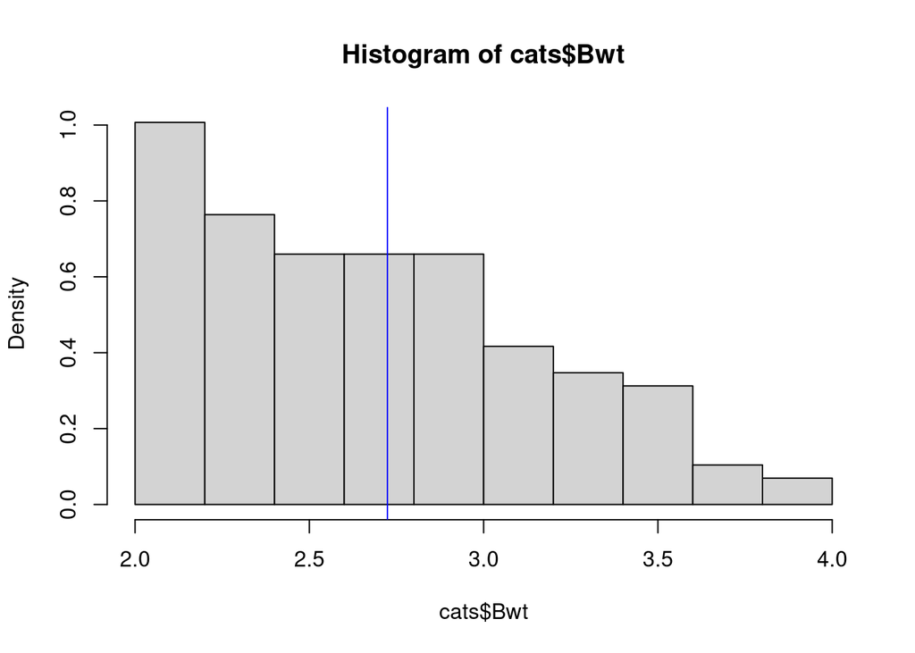

```r
#hist for the body weights
hist(cats$Bwt, probability = TRUE)
abline(v=2.724, col = "blue")
```

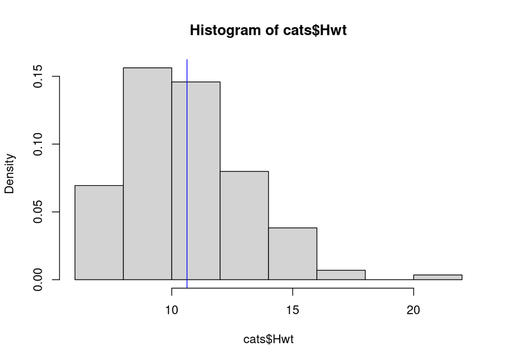

```r
#hist for the heart weights
hist(cats$Hwt, probability = TRUE)
abline(v=10.63, col = "blue")
```

```r
"in both cases the means look correct."
```

```
## [1] "in both cases the means look correct."
```

##### Problem 3. (10 points)

Define two variables, `fake.mean <- 10` and `fake.var <- 8`. Write an expression for $a$ using these placeholder values. Does it equal what you expected given the solutions above? Once it does, write another such expression for $s$ and confirm.

##### Solution

Type your answer here

```r
fake.mean = 10
fake.var = 8
a = fake.mean^2/fake.var
s = fake.var/fake.mean
a
```

```
## [1] 12.5
```

```r
s
```

```
## [1] 0.8
```

##### Problem 4. (10 points)

Calculate the mean, standard deviation, and variance of the heart weights using R’s existing functions for these tasks. Plug the mean and variance of the cats’ hearts into your formulas from the previous question and get estimates of $a$ and $s$. What are they? Do not report them to more significant digits than is reasonable.

##### Solution

Type your answer here

```r
mean(cats$Hwt)
```

```
## [1] 10.63056
```

```r
sd(cats$Hwt)
```

```
## [1] 2.434636
```

```r
var(cats$Hwt)
```

```
## [1] 5.927451
```

```r
a = mean(cats$Hwt)^2/var(cats$Hwt)
s = var(cats$Hwt)/mean(cats$Hwt)
a
```

```
## [1] 19.06531
```

```r
s
```

```
## [1] 0.5575862
```

##### Problem 5. (10 points)

Write a function, `cat.stats()`, which takes as input a vector of numbers and returns the mean and variances of these cat hearts. (You can use the existing mean and variance functions within this function.) Confirm that you are returning the values from above.

##### Solution

Type your answer here

```r
cats.stats = function(x){
  mean = mean(x)
  var = var(x)
  return(list(mean, var))
}
cats.stats(cats$Hwt)
```

```
## [[1]]
## [1] 10.63056
##
## [[2]]
## [1] 5.927451
```

# Part II

##### Problem 6. (10 points)

Now, use your existing function as a template for a new function, `gamma.cat()`, that calculates the mean and variances and returns the estimate of $a$ and $s$. What estimates does it give on the cats’ hearts weight? Should it agree with your previous calculation?

##### Solution

Type your answer here

```r
gamma.cat = function(x){
  mean = mean(x)
  var = var(x)
  a = mean^2/var
  s = var/mean
  return(list(a,s))
}
gamma.cat(cats$Hwt)
```

```
## [[1]]
## [1] 19.06531
##
## [[2]]
## [1] 0.5575862
```

```r
"it does agree with my previous calculations"
```

```
## [1] "it does agree with my previous calculations"
```

##### Problem 7. (10 points)

Estimate the $a$ and $s$ separately for all the male cats and all the female cats, using `gamma.cat()`. Give the commands you used and the results.

##### Solution

Type your answer here

```r
male = cats$Hwt[cats$Sex=="M"]
fmale = cats$Hwt[cats$Sex=="F"]
gamma.cat(male)
```

```
## [[1]]
## [1] 19.83576
##
## [[2]]
## [1] 0.5708216
```

```r
gamma.cat(fmale)
```

```
## [[1]]
## [1] 45.93998
##
## [[2]]
## [1] 0.2003076
```

##### Problem 8. (10 points)

Now, produce a histogram for the female cats. On top of this, add the shape of the gamma PDF using `curve()` with its first argument as `dgamma()`, the known PDF for the Gamma distribution. Is this distribution consistent with the empirical probability density of the histogram?

##### Solution

Type your answer here

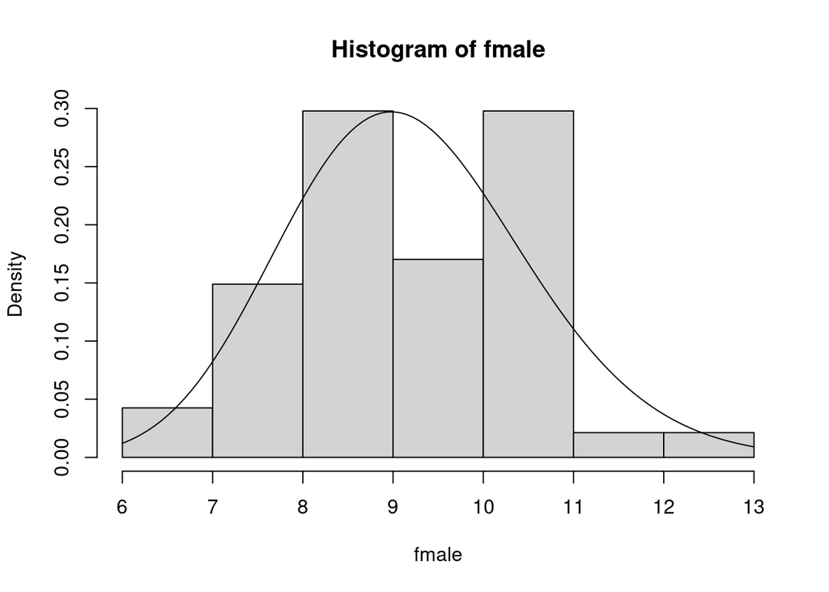

```r
hist(fmale, probability = TRUE)
curve(dgamma(x,shape = 45.9,scale = 0.2),6,13,add = TRUE)
```

```r
"the density curve doesnt perfectly fit the histogram"
```

```
## [1] "the density curve doesnt perfectly fit the histogram"
```

##### Problem 9. (10 points)

Repeat the previous step for male cats. How do the distributions compare?

##### Solution

Type your answer here

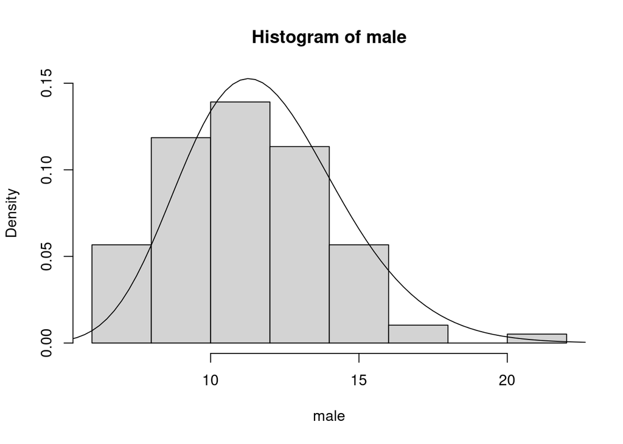

```r
hist(male, probability = TRUE, ylim=c(0,.15))
curve(dgamma(x,shape = 19.8,scale = 0.6),0,25,add = TRUE)
```

```r
"the density curve fits better for the male cats"
```

```
## [1] "the density curve fits better for the male cats"
```